# NIMBLE Example

This notebook presents an abbreviated reworking of the Pump Failure model presented in Chapter 2 of the [NIMBLE Manual](https://r-nimble.org/manuals/NimbleUserManual.pdf). Note that although [NIMBLE](https://r-nimble.org/) is an R package, listed on CRAN, that installs like any other R package, you must have a C++ compiler and the standard `make` utility installed on your system before installing NIMBLE. See Chapter 4 of the manual for platform-specific installation instructions

### Pump Failure Model

The Pump Failure model is dsicussed by George et al. in their 1993 paper: [Conjugate Likelihood Distributions](https://www.jstor.org/stable/4616270?seq=1#page_scan_tab_contents). The paper examines Bayesian models that use conjugate priors, but which do not have closed form solutions when prior distributions are associated with the hyperparameters. The [BUGS](http://www.openbugs.net/w/FrontPage) solution of the problem is given [here](http://www.openbugs.net/Examples/Pumps.html).

The data driving the model are: `x[i]` the number of failures for pump `i` in a time interval `t[i]` where `i` goes from 1 to 10.

```r
library(nimble)
library(igraph)
library(tidyverse)
pumpConsts <- list(N = 10,
t = c(94.3, 15.7, 62.9, 126, 5.24,31.4, 1.05, 1.05, 2.1, 10.5))
pumpData <- list(x = c(5, 1, 5, 14, 3, 19, 1, 1, 4, 22))
```

Arrival times as a Poisson distribution with parameter `lambda` where `lambda` is itself modeled as a Gamma distribution with hyperparameters `alpha` and `beta`.

The model is expressed in the `BUGS` language wrapped inside the NIMBLE function `nimbleCode()` which turns the `BUGS` code into a object that can be operated on by `nimbleModel()`

```r
pumpCode <- nimbleCode(
  {
for (i in 1:N){
  theta[i] ~ dgamma(alpha,beta)
  lambda[i] <- theta[i]*t[i]
  x[i] ~ dpois(lambda[i])
  }
alpha ~ dexp(1.0)
beta ~ dgamma(0.1,1.0)
})
pumpInits <- list(alpha = 1, beta = 1,
theta = rep(0.1, pumpConsts$N))
```

`nimbleModel()` produces the model object that can be executed by `R` or compiled.

```r
pump <- nimbleModel(code = pumpCode, name = "pump", constants = pumpConsts,
                    data = pumpData, inits = pumpInits)
```

```
defining model...
building model...
setting data and initial values...
running calculate on model (any error reports that follow may simply reflect missing values in model variables) ...
checking model sizes and dimensions...
model building finished.
```

The following command lets us look at the nodes that comprise the model’s directed graph and plot it.

```r
pump$getNodeNames()
```

```
 [1] "alpha"               "beta"                "lifted_d1_over_beta" "theta[1]"
 [5] "theta[2]"            "theta[3]"            "theta[4]"            "theta[5]"
 [9] "theta[6]"            "theta[7]"            "theta[8]"            "theta[9]"
[13] "theta[10]"           "lambda[1]"           "lambda[2]"           "lambda[3]"
[17] "lambda[4]"           "lambda[5]"           "lambda[6]"           "lambda[7]"
[21] "lambda[8]"           "lambda[9]"           "lambda[10]"          "x[1]"
[25] "x[2]"                "x[3]"                "x[4]"                "x[5]"
[29] "x[6]"                "x[7]"                "x[8]"                "x[9]"
[33] "x[10]"
```

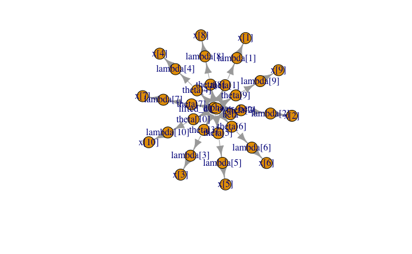

```r
pump$plotGraph()
```

We can look at the values stored at each node. The node for `x` contains the initial values we entered into the model and the nodes for `theta` and `lambda` contain the initial calculated values

```r
pump$x
```

```
 [1]  5  1  5 14  3 19  1  1  4 22
```

```r
pump$theta
```

```
 [1] 0.1 0.1 0.1 0.1 0.1 0.1 0.1 0.1 0.1 0.1
```

```r
pump$lambda
```

```
 [1]  9.430  1.570  6.290 12.600  0.524  3.140  0.105  0.105  0.210
[10]  1.050
```

We can also look at the log probabilities of the likelihoods.

```r
pump$logProb_x
```

```
 [1]  -2.998011  -1.118924  -1.882686  -2.319466  -4.254550
 [6] -20.739651  -2.358795  -2.358795  -9.630645 -48.447798
```

```r
set.seed(1)
pump$simulate("theta")
pump$theta
```

```
 [1] 0.15514136 1.88240160 1.80451250 0.83617765 1.22254365 1.15835525 0.99001994 0.30737332 0.09461909
[10] 0.15720154
```

```r
pump$lambda
```

```
 [1]  9.430  1.570  6.290 12.600  0.524  3.140  0.105  0.105  0.210  1.050
```

```r
pump$logProb_x
```

```
 [1]  -2.998011  -1.118924  -1.882686  -2.319466  -4.254550 -20.739651  -2.358795  -2.358795  -9.630645
[10] -48.447798
```

We can also compile the model. The C++ code generated is loaded back into R with an object that can be examined like the uncompiled model.

```r
Cpump <- compileNimble(pump)
```

```
compiling... this may take a minute. Use 'showCompilerOutput = TRUE' to see C++ compiler details.
compilation finished.
```

```r
Cpump$theta
```

```
 [1] 0.15514136 1.88240160 1.80451250 0.83617765 1.22254365 1.15835525 0.99001994 0.30737332 0.09461909
[10] 0.15720154
```

Now, we use the default NIMBLE MCMC algorithm to generate posterior samples from the distributions for the model parameters `alpha`, `beta`, `theta` and `lambda` along with summary statistics, and the value of Wantanabi’s WAIC statistic.

```r
mcmc.out <- nimbleMCMC(code = pumpCode, constants = pumpConsts,
                       data = pumpData, inits = pumpInits,
                       monitors=c("alpha","beta","theta","lambda"),
                       nchains = 2, niter = 10000,
                       summary = TRUE, WAIC = TRUE)
```

```
defining model...
building model...
setting data and initial values...
running calculate on model (any error reports that follow may simply reflect missing values in model variables) ...
checking model sizes and dimensions...
checking model calculations...
model building finished.
Monitored nodes are valid for WAIC.
compiling... this may take a minute. Use 'showCompilerOutput = TRUE' to see C++ compiler details.
compilation finished.
running chain 1...
```

```
|-------------|-------------|-------------|-------------|
|-------------------------------------------------------|
```

```
running chain 2...
```

```
|-------------|-------------|-------------|-------------|
|-------------------------------------------------------|
```

```r
names(mcmc.out)
```

```
[1] "samples" "summary" "WAIC"
```

```r
mcmc.out$summary
```

```
$chain1
                  Mean      Median    St.Dev.    95%CI_low  95%CI_upp
alpha       0.69804352  0.65835063 0.27037676  0.287898244  1.3140461
beta        0.92862598  0.82156847 0.54969128  0.183699137  2.2872696
lambda[1]   5.67617535  5.35277649 2.39989346  1.986896247 11.3087435
lambda[2]   1.59476464  1.28802618 1.24109695  0.126649837  4.7635134
lambda[3]   5.58222072  5.28139948 2.36539331  1.961659802 11.1331869
lambda[4]  14.57540796 14.23984600 3.79587390  8.085538041 22.9890092
lambda[5]   3.16402849  2.87859865 1.63590766  0.836991007  7.1477641
lambda[6]  19.21831706 18.86685281 4.33423677 11.703168568 28.6847447
lambda[7]   0.94776605  0.74343559 0.77658191  0.077828283  2.8978174
lambda[8]   0.93472103  0.74313533 0.76301563  0.076199581  2.9598715
lambda[9]   3.31124086  3.03219017 1.61332897  0.955909813  7.2024472
lambda[10] 20.89018329 20.59798130 4.45302924 13.034529765 30.4628012
theta[1]    0.06019274  0.05676327 0.02544956  0.021069950  0.1199230
theta[2]    0.10157737  0.08203988 0.07905076  0.008066869  0.3034085
theta[3]    0.08874755  0.08396502 0.03760562  0.031186960  0.1769982
theta[4]    0.11567784  0.11301465 0.03012598  0.064170937  0.1824525
theta[5]    0.60382223  0.54935089 0.31219612  0.159731108  1.3640771
theta[6]    0.61204831  0.60085518 0.13803302  0.372712375  0.9135269
theta[7]    0.90263434  0.70803389 0.73960182  0.074122175  2.7598261
theta[8]    0.89021051  0.70774794 0.72668155  0.072571029  2.8189252
theta[9]    1.57678136  1.44390008 0.76825189  0.455195149  3.4297368
theta[10]   1.98954127  1.96171250 0.42409802  1.241383787  2.9012192

$chain2
                  Mean      Median    St.Dev.    95%CI_low  95%CI_upp
alpha       0.69101961  0.65803654 0.26548378  0.277195564  1.2858148
beta        0.91627273  0.81434426 0.53750825  0.185772263  2.2702428
lambda[1]   5.59893463  5.29143956 2.32153991  1.976164994 10.9564380
lambda[2]   1.57278293  1.27425268 1.23323878  0.129781580  4.7262566
lambda[3]   5.60321125  5.27780200 2.32992322  1.970709123 10.9249502
lambda[4]  14.60674094 14.30971897 3.86145332  8.013012004 23.0526313
lambda[5]   3.13119513  2.84685917 1.67006926  0.782262325  7.2043337
lambda[6]  19.17917926 18.82326155 4.33456380 11.661139736 28.5655803
lambda[7]   0.94397897  0.74446578 0.76576887  0.080055678  2.8813517
lambda[8]   0.94452324  0.74263433 0.77013200  0.074813473  2.9457364
lambda[9]   3.30813061  3.04512049 1.58008544  0.986914665  7.0355869
lambda[10] 20.88570471 20.60384141 4.44130984 13.092562597 30.5574424
theta[1]    0.05937364  0.05611283 0.02461866  0.020956151  0.1161870
```

[output cut: 19 more lines]

```
lambda[6]  19.19874816 18.84484055 4.33433610 11.68198222 28.6445471
lambda[7]   0.94587251  0.74395440 0.77117739  0.07927988  2.8911629
lambda[8]   0.93962214  0.74299160 0.76657858  0.07571751  2.9470742
lambda[9]   3.30968573  3.03910484 1.59675456  0.97386482  7.1120082
lambda[10] 20.88794400 20.60051118 4.44706278 13.05509616 30.5216406
theta[1]    0.05978319  0.05646474 0.02504028  0.02102807  0.1183433
theta[2]    0.10087731  0.08162361 0.07880204  0.00811108  0.3017967
theta[3]    0.08891440  0.08394667 0.03732417  0.03123228  0.1749967
theta[4]    0.11580218  0.11326039 0.03038683  0.06385253  0.1827382
theta[5]    0.60068928  0.54668011 0.31548032  0.15363752  1.3686801
theta[6]    0.61142510  0.60015416 0.13803618  0.37203765  0.9122467
theta[7]    0.90083096  0.70852800 0.73445465  0.07550465  2.7534885
theta[8]    0.89487822  0.70761105 0.73007484  0.07211191  2.8067373
theta[9]    1.57604083  1.44719278 0.76035931  0.46374515  3.3866706
theta[10]   1.98932800  1.96195345 0.42352979  1.24334249  2.9068229
```

```r
mcmc.out$WAI
```

```
[1] 48.69896
```

Here, we select sample values for the parameters for pump 1 in the first chain and put them into a data frame for plotting.

```r
df <- data.frame(mcmc.out$samples$chain1)
df_l <- df %>% select(alpha, beta, theta.1., lambda.1.) %>% gather(key="parameter", value="value")
```

We plot the sample values.

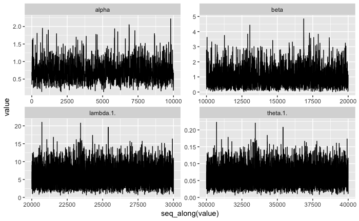

```r
ps <- df_l %>% ggplot(aes(x=seq_along(value), y = value)) + geom_line()
ps + facet_wrap(~parameter, scales = "free")
```

And, we plot histograms.

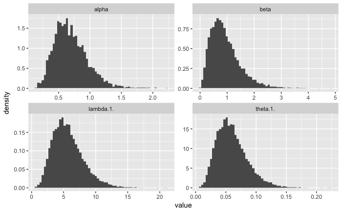

```r
p <- ggplot(df_l,aes(value)) + geom_histogram(aes( y= ..density..),bins = 60)
p + facet_wrap(~parameter, scales = "free")
```

```r
NA
```

Note that it is also possible to perform the MCMC simulation using the compiled model.

```r
mcmc.out_c<- nimbleMCMC(model=Cpump,
                       monitors=c("alpha","beta","theta","lambda"),
                       nchains = 2, niter = 10000,
                       summary = TRUE, WAIC = TRUE)
```

```
Monitored nodes are valid for WAIC.
compiling... this may take a minute. Use 'showCompilerOutput = TRUE' to see C++ compiler details.
compilation finished.
running chain 1...
```

```
|-------------|-------------|-------------|-------------|
|-------------------------------------------------------|
```

```
running chain 2...
```

```
|-------------|-------------|-------------|-------------|
|-------------------------------------------------------|
```

```r
mcmc.out_c$summary
```

```
$chain1
                  Mean      Median    St.Dev.    95%CI_low  95%CI_upp
alpha       0.68289275  0.64325051 0.26593120  0.285717690  1.3260252
beta        0.90059340  0.79968676 0.52918408  0.172295478  2.1958411
lambda[1]   5.65958791  5.29156915 2.40459280  1.973502981 11.3038583
lambda[2]   1.59302890  1.28348714 1.25578893  0.131692895  4.8521120
lambda[3]   5.62935775  5.33938338 2.34748964  1.982309285 11.0758361
lambda[4]  14.64133845 14.34758283 3.84179565  8.067961017 22.9848201
lambda[5]   3.15400973  2.85311844 1.68179472  0.751105923  7.2829039
lambda[6]  19.13166319 18.77017294 4.30633575 11.754096648 28.4410246
lambda[7]   0.93956847  0.73388999 0.75993459  0.080391825  2.8775931
lambda[8]   0.94614100  0.74537768 0.77746238  0.071307067  2.9521831
lambda[9]   3.35412184  3.07015929 1.63773762  0.982697950  7.3036628
lambda[10] 21.03190576 20.71356837 4.50342909 13.146880038 30.6942924
theta[1]    0.06001684  0.05611420 0.02549939  0.020927921  0.1198712
theta[2]    0.10146681  0.08175077 0.07998656  0.008388082  0.3090517
theta[3]    0.08949694  0.08488686 0.03732098  0.031515251  0.1760864
theta[4]    0.11620110  0.11386970 0.03049044  0.064031437  0.1824192
theta[5]    0.60191025  0.54448825 0.32095319  0.143340825  1.3898672
theta[6]    0.60928864  0.59777621 0.13714445  0.374334288  0.9057651
theta[7]    0.89482711  0.69894285 0.72374723  0.076563643  2.7405649
theta[8]    0.90108667  0.70988350 0.74044036  0.067911492  2.8116030
theta[9]    1.59720088  1.46198061 0.77987506  0.467951405  3.4779346
theta[10]   2.00303864  1.97272080 0.42889801  1.252083813  2.9232659

$chain2
                  Mean      Median    St.Dev.    95%CI_low  95%CI_upp
alpha       0.70058383  0.65890424 0.27281946  0.288269787  1.3536169
beta        0.93302533  0.82937546 0.54723014  0.186925716  2.2704157
lambda[1]   5.64700391  5.30444945 2.37250836  2.022381592 11.2079994
lambda[2]   1.61771268  1.30194222 1.25337481  0.130337701  4.8137040
lambda[3]   5.64785636  5.30834322 2.35185018  1.949165786 11.1287853
lambda[4]  14.57771982 14.28016620 3.80617400  8.016174556 22.8297703
lambda[5]   3.14784276  2.84559701 1.65276445  0.806534769  7.1241991
lambda[6]  19.12817114 18.86114705 4.28360285 11.631021188 28.3497039
lambda[7]   0.93038563  0.73348129 0.75119578  0.081534634  2.8697437
lambda[8]   0.93016378  0.72953025 0.76477640  0.073619976  2.9029431
lambda[9]   3.33320916  3.06711457 1.62188650  1.022633757  7.2190789
lambda[10] 20.89389172 20.57163980 4.46552015 13.148228163 30.5472216
theta[1]    0.05988339  0.05625079 0.02515916  0.021446252  0.1188547
```

[output cut: 19 more lines]

```
lambda[6]  19.12991716 18.80468304 4.29487731 11.690545585 28.3963517
lambda[7]   0.93497705  0.73356348 0.75557288  0.080795340  2.8725055
lambda[8]   0.93815239  0.73672619 0.77116758  0.072199887  2.9240082
lambda[9]   3.34366550  3.06926643 1.62982413  1.000032903  7.2710561
lambda[10] 20.96289874 20.64566856 4.48493350 13.146880038 30.6278635
theta[1]    0.05995012  0.05619750 0.02532930  0.021177564  0.1194419
theta[2]    0.10225292  0.08235588 0.07991158  0.008333475  0.3080092
theta[3]    0.08964399  0.08462854 0.03735501  0.031212670  0.1764687
theta[4]    0.11594864  0.11358340 0.03034971  0.063794122  0.1818713
theta[5]    0.60132180  0.54358596 0.31818777  0.148278721  1.3738295
theta[6]    0.60923303  0.59887526 0.13677953  0.372310369  0.9043424
theta[7]    0.89045433  0.69863189 0.71959322  0.076947943  2.7357195
theta[8]    0.89347847  0.70164400 0.73444531  0.068761797  2.7847697
theta[9]    1.59222167  1.46155545 0.77610673  0.476206144  3.4624077
theta[10]   1.99646655  1.96625415 0.42713652  1.252083813  2.9169394
```

### Monte Carlo Expectation Analysis

Finally, to illustrate that NIMBLE is more than just an MCMC engine we NIMBLE’s built-in Monte Carlo Expectation algorithm to maxime the marginal likelihood for `alpha` and `beta`. First, we create a new model and set up the “box constraints”. Then, the `buildMCEM()` function is used to construct an MCEM algorithm from a NIMBLE model.

```r
pump2 <- pump$newModel()
```

```
setting data and initial values...
running calculate on model (any error reports that follow may simply reflect missing values in model variables) ...
checking model sizes and dimensions...
```

```r
box = list( list(c("alpha","beta"), c(0, Inf)))
pumpMCEM <- buildMCEM(model = pump2, latentNodes = "theta[1:10]", boxConstraints = box)
```

```
compiling... this may take a minute. Use 'showCompilerOutput = TRUE' to see C++ compiler details.
compilation finished.
compiling... this may take a minute. Use 'showCompilerOutput = TRUE' to see C++ compiler details.
compilation finished.
compiling... this may take a minute. Use 'showCompilerOutput = TRUE' to see C++ compiler details.
compilation finished.
compiling... this may take a minute. Use 'showCompilerOutput = TRUE' to see C++ compiler details.
compilation finished.
compiling... this may take a minute. Use 'showCompilerOutput = TRUE' to see C++ compiler details.
compilation finished.
```

Now, we run the model.

```r
pumpMLE <- pumpMCEM$run()
```

```
|-------------|-------------|-------------|-------------|
|-------------------------------------------------------|
Iteration Number: 1.
Current number of MCMC iterations: 1000.
Parameter Estimates:
    alpha      beta
0.8176016 1.1282621
Convergence Criterion: 1.001.
|-------------|-------------|-------------|-------------|
|-------------------------------------------------------|
Iteration Number: 2.
Current number of MCMC iterations: 1000.
Parameter Estimates:
    alpha      beta
0.8108633 1.2147701
Convergence Criterion: 0.02009882.
|-------------|-------------|-------------|-------------|
|-------------------------------------------------------|
Monte Carlo error too big: increasing MCMC sample size.
|-------------|-------------|-------------|-------------|
|-------------------------------------------------------|
Iteration Number: 3.
Current number of MCMC iterations: 1250.
Parameter Estimates:
    alpha      beta
0.8164272 1.2396202
Convergence Criterion: 0.001636484.
|-------------|-------------|-------------|-------------|
|-------------------------------------------------------|
Iteration Number: 4.
Current number of MCMC iterations: 1250.
Parameter Estimates:
    alpha      beta
0.8296219 1.2743850
Convergence Criterion: 0.002725937.
|-------------|-------------|-------------|-------------|
|-------------------------------------------------------|
Monte Carlo error too big: increasing MCMC sample size.
|-------------|-------------|-------------|-------------|
|-------------------------------------------------------|
```

[output cut: 8 more lines]

```
Monte Carlo error too big: increasing MCMC sample size.
|-------------|-------------|-------------|-------------|
|-------------------------------------------------------|
Monte Carlo error too big: increasing MCMC sample size.
|-------------|-------------|-------------|-------------|
|-------------------------------------------------------|
Monte Carlo error too big: increasing MCMC sample size.
|-------------|-------------|-------------|-------------|
|-------------------------------------------------------|
Iteration Number: 6.
Current number of MCMC iterations: 4298.
Parameter Estimates:
    alpha      beta
0.8269162 1.2647309
Convergence Criterion: 0.0005229331.
```

The authors of the NIMBLE manual point out that these results are within 0.01 of the values obtained by Geroge et al..